# Sup_Learning

## Modeling Strategies Assignment & Supervised ML

Check [my google slides](https://docs.google.com/presentation/d/1vo7nNJy0YRaj7Fi7C04BRnRxw5LXRGJjILlcpZ2IeaU/edit?usp=sharing) to grab a quick understanding about this assignment

Objectives:

- Apply in-memory distributed computational tool *H2O*
- Learn hyperparameter-tuning in Random Forest model
- Evaluate models using Gains and Lift table
- Implement varieous sampling techniques
- Understand the impact of under/over sampling

## Import libraries and define auxiliary functions

```python
# basic
import pandas as pd
import numpy as np
from datetime import datetime
# H2o
import h2o
# plot
import matplotlib.pyplot as plt
import pylab as pl
# sklearn
from sklearn.decomposition import PCA
# model evaluation
from sklearn.metrics import *
import warnings; warnings.filterwarnings("ignore")
```

```python
pd.__version__
```

```
'1.4.4'
```

### Pre-defined Functions

```python
def VarImp(model_name):

    from sklearn.metrics import roc_curve,auc
    from sklearn.metrics import average_precision_score
    from sklearn.metrics import precision_recall_curve
    import matplotlib.pyplot as plt

    # plot the variable importance
    plt.rcdefaults()
    variables = model_name._model_json['output']['variable_importances']['variable']
    y_pos = np.arange(len(variables))
    fig, ax = plt.subplots(figsize = (6,len(variables)/2))
    scaled_importance = model_name._model_json['output']['variable_importances']['scaled_importance']
    ax.barh(y_pos,scaled_importance,align='center',color='green')
    ax.set_yticks(y_pos)
    ax.set_yticklabels(variables)
    ax.invert_yaxis()
    ax.set_xlabel('Scaled Importance')
    ax.set_title('Variable Importance')
    plt.show()
```

```python
def createGains(model):
    predictions = model.predict(test)
    test_scores = test['loan_default'].cbind(predictions).as_data_frame()

    #sort on prediction (descending), add id, and decile for groups containing 1/10 of datapoints
    test_scores = test_scores.sort_values(by='predict',ascending=False)
    test_scores['row_id'] = range(0,0+len(test_scores))
    test_scores['decile'] = ( test_scores['row_id'] / (len(test_scores)/10) ).astype(int)
    #see count by decile
    test_scores.loc[test_scores['decile'] == 10]=9
    test_scores['decile'].value_counts()

    #create gains table
    gains = test_scores.groupby('decile')['loan_default'].agg(['count','sum'])
    gains.columns = ['count','actual']
    gains

    #add features to gains table
    gains['non_actual'] = gains['count'] - gains['actual']
    gains['cum_count'] = gains['count'].cumsum()
    gains['cum_actual'] = gains['actual'].cumsum()
    gains['cum_non_actual'] = gains['non_actual'].cumsum()
    gains['percent_cum_actual'] = (gains['cum_actual'] / np.max(gains['cum_actual'])).round(2)
    gains['percent_cum_non_actual'] = (gains['cum_non_actual'] / np.max(gains['cum_non_actual'])).round(2)
    gains['if_random'] = np.max(gains['cum_actual']) /10
    gains['if_random'] = gains['if_random'].cumsum()
    gains['lift'] = (gains['cum_actual'] / gains['if_random']).round(2)
    gains['K_S'] = np.abs( gains['percent_cum_actual'] -  gains['percent_cum_non_actual'] ) * 100
    gains['gain']=(gains['cum_actual']/gains['cum_count']*100).round(2)
    gains = pd.DataFrame(gains)
    return(gains)
```

```python
def ROC_AUC1(my_result,df,target):
    # ROC
    y_actual = df[target].as_data_frame()
    y_pred = my_result.predict(df).as_data_frame()['p1']
    fpr = list()
    tpr = list()
    roc_auc = list()
    fpr,tpr,_ = roc_curve(y_actual,y_pred)
    roc_auc = auc(fpr,tpr)

    # Precision-Recall
    average_precision = average_precision_score(y_actual,y_pred)

    print('')
    print('   * ROC curve: The ROC curve plots the true positive rate vs. the false rositive sate')
    print('')
    print('	  * The area under the curve (AUC): A value between 0.5 (random) and 1.0 (perfect), measuring the prediction accuracy')
    print('')
    print('   * Recall (R) = The number of true positives / (the number of true positives + the number of false negatives)')
    print('')

    # plotting
    plt.figure(figsize=(14,6))

    # ROC
    plt.subplot(1,2,1)
    plt.plot(fpr,tpr,color='darkorange',lw=2,label='ROC curve (aare=%0.2f)' % roc_auc)
    plt.plot([0,1],[0,1],color='navy',lw=3,linestyle='--')
    plt.xlim([0.0,1.0])
    plt.ylim([0.0,1.05])
    plt.xlabel('False Positive Rate')
    plt.ylabel('True Positive Rate')
    plt.title('Receiver operating characteristic: AUC={0:0.4f}'.format(roc_auc))
    plt.legend(loc='lower right')

    # Precision-Recall
    plt.subplot(1,2,2)
    precision,recall,_ = precision_recall_curve(y_actual,y_pred)
    plt.step(recall,precision,color='b',alpha=0.2,where='post')
    plt.fill_between(recall,precision,step='post',alpha=0.2,color='b')
    plt.xlabel('Recall')
    plt.ylabel('Precision')
    plt.ylim([0.0,1.05])
    plt.xlim([0.0,1.0])
    plt.title('Precision-Recall curve: PR={0:0.4f}'.format(average_precision))
    plt.show()
```

```python
def plot_this(X_rs,y_rs,method):
    # Use principal component to condense the 10 features to 2 features
    pca = PCA(n_components=2).fit(X_rs)
    pca_2d = pca.transform(X_rs)
    # Assign colors
    for i in range(0, pca_2d.shape[0]):
        if y_rs['loan_default'][i] == 0:
            c1 = pl.scatter(pca_2d[i,0],pca_2d[i,1],c='r', marker='o')
        elif y_rs['loan_default'][i] == 1:
            c2 = pl.scatter(pca_2d[i,0],pca_2d[i,1],c='g', marker='*')
    pl.legend([c1, c2], ['Not Default', 'Default'])
    pl.title(method)
    pl.axis([-4, 5, -4, 4])  # x axis (-4,5), y axis (-4,4)
    pl.show()
```

```python
def H2odf(x_train, x_test, y_train, y_test):
    x_train1 = x_train.copy()
    x_train1['loan_default'] = y_train
    x_train1 = h2o.H2OFrame(x_train1)
    train, valid = x_train1.split_frame(ratios=[.8], seed=0)
    # test
    x_test1 = x_test.copy()
    x_test1['loan_default'] = y_test
    test = h2o.H2OFrame(x_test1)
    return train, valid, test
```

## Read & Inspect Data

```python
# read prepared data
x_train = pd.read_csv('X_train.csv')
x_test = pd.read_csv('X_test.csv')
y_train = pd.read_csv('y_train.csv')
y_test = pd.read_csv('y_test.csv')
```

```python
x_train.shape
```

```
(64000, 160)
```

```python
pd.set_option('display.max_columns', None)
x_train.tail(3)
```

|  | id | AP001 | AP002 | AP003 | AP004 | AP005 | AP006 | AP007 | AP008 | AP009 | TD001 | TD002 | TD005 | TD006 | TD009 | TD010 | TD013 | TD014 | TD015 | TD022 | TD023 | TD024 | TD025 | TD026 | TD027 | TD028 | TD029 | CR004 | CR005 | … |
| --- | --- | --- | --- | --- | --- | --- | --- | --- | --- | --- | --- | --- | --- | --- | --- | --- | --- | --- | --- | --- | --- | --- | --- | --- | --- | --- | --- | --- | --- | --- |
| 63997 | 43163 | 31 | 1 | 1 | 12 | 2017/6/30 23:30 | ios | 3 | 5 | 0 | 0 | 0 | 6 | 1 | 7 | 5 | 15 | 10 | 4 | 15.0 | 21.0 | 14.0 | 0.0 | 0.0 | 0.0 | 0.0 | 6.0 | 3 | 1 | … |
| 63998 | 20716 | 23 | 2 | 3 | 12 | 2017/6/1 11:26 | android | 5 | 5 | 1 | 1 | 1 | 1 | 1 | 2 | 1 | 6 | 1 | 1 | 15.0 | 0.0 | 2.0 | 0.0 | 0.0 | 0.0 | 0.0 | 6.0 | 2 | 1 | … |
| 63999 | 14754 | 24 | 2 | 3 | 12 | 2017/5/4 17:10 | h5 | 4 | 4 | 1 | 3 | 1 | 4 | 2 | 7 | 4 | 8 | 7 | 1 | 20.0 | 6.0 | 12.0 | 0.0 | 0.0 | 0.0 | 0.0 | 6.0 | 2 | 1 | … |

```python
x_train.info(verbose=True)
```

```
<class 'pandas.core.frame.DataFrame'>
RangeIndex: 64000 entries, 0 to 63999
Data columns (total 160 columns):
 #    Column     Dtype
---   ------     -----
 0    id         int64
 1    AP001      int64
 2    AP002      int64
 3    AP003      int64
 4    AP004      int64
 5    AP005      object
 6    AP006      object
 7    AP007      int64
 8    AP008      int64
 9    AP009      int64
```

[output cut: 152 more lines]

```python
# check the distribution of the target variable
y_train.value_counts()
```

```
loan_default
0               51610
1               12390
dtype: int64
```

```python
ratio = round(12390 / 51610 * 100, 2)
print(f'In the train dataset, loan default cases are about {ratio}% of all investigations')
```

[output not shown]

## Data Preprocessing

**Data Selection Methods**:

1. keep only original features (total of 78)
2. keep original features and bin variables (total of 113)
3. keep everything (total of 160)

**Processing Methods**:

1. time series encoding, H2O will encode all categorical variables with a selected method
2. apply time series encoding, categorical encoding (one-hot encoding, frequency encoding)

**Feature Selection (failed)**: These methods did not make the model performs better

1. 1% as threshold to exclude weak predictors (using .corr())
2. PCA 95%, 99% variance covered
3. Autoencoder :(

### Only Original Features

```python
x_train = x_train.iloc[:, 0:79]
x_test = x_test.iloc[:, 0:79]
```

### Drop Bin Variables (Optional)

```python
# find bin variables
# bin_vars = [i for i in list(x_train.columns) if 'bin' in i]
# drop bin variables
# x_train = x_train.drop(bin_vars, axis=1)
# x_test = x_test.drop(bin_vars, axis=1)
```

### Drop WOE & Iv (Optional)

```python
# find bin variables
# woe_vars = [i for i in list(x_train.columns) if 'woe' in i]
# iv_vars = [i for i in list(x_train.columns) if 'iv' in i]
# combine
# woe_iv = list(set().union(woe_vars, iv_vars))
# drop bin variables
# x_train = x_train.drop(woe_iv, axis=1)
# x_test = x_test.drop(woe_iv, axis=1)
```

```python
# x_train.shape
```

[output not shown]

### AP006 Onehot Encoding (Optional)

```python
x_train.AP006.unique()
```

```
array(['android', 'h5', 'ios', 'api'], dtype=object)
```

```python
x_train = pd.get_dummies(x_train, columns=['AP006'] , drop_first=True)
x_test = pd.get_dummies(x_test, columns=['AP006'] , drop_first=True)
```

### MB007 Frequency Encoding (Optional)

```python
x_train.MB007.value_counts()
```

```
WEB            35129
IPHONE7         5072
IPHONE8         4149
OPPO            3473
IPHONE9         3372
               ...
VOLTE              1
OWWO               1
OUKI               1
CHINAMOBILE        1
VEGA               1
Name: MB007, Length: 100, dtype: int64
```

Since this variable has so many unique values, we will not use one hot encoding, instead we use frequency encoding

```python
# frequency encoding
fren = (x_train.groupby('MB007').size()) / len(x_train)
fren
```

```
MB007
360       0.001328
4G        0.000047
ALPS      0.000063
AMOI      0.000016
AND       0.000016
            ...
YU-FLY    0.000031
YUFLY     0.000047
ZTE       0.000937
ZUK       0.000125
ZUOKU     0.000016
Length: 100, dtype: float64
```

```python
x_train['MB007_fren'] = x_train['MB007'].apply(lambda x : fren[x])
# apply the same label to test, assign 0 to any new values
x_test['MB007_fren'] = x_test['MB007'].apply(lambda x : fren[x] if x in fren.index else 0)
```

```python
x_train = x_train.drop('MB007', axis=1)
x_test = x_test.drop('MB007', axis=1)
```

### AP005 (Time Series Variable)

```python
# make AP005 datetime
x_train['AP005'] = pd.to_datetime(x_train['AP005'])
x_test['AP005'] = pd.to_datetime(x_test['AP005'])
```

```python
x_train.AP005.head()
```

```
0   2017-05-04 07:13:00
1   2017-04-27 19:33:00
2   2017-07-01 09:26:00
3   2017-04-06 21:45:00
4   2017-05-09 18:14:00
Name: AP005, dtype: datetime64[ns]
```

```python
# split it into year, month, day, time
x_train['AP005_month'] = x_train['AP005'].apply(lambda x: x.month)
x_train['AP005_day'] = x_train['AP005'].apply(lambda x: x.day)
x_train['AP005_hour'] = x_train['AP005'].apply(lambda x: x.hour)
x_train['AP005_daytime'] = np.where((18 >= x_train['AP005_hour']) & (x_train['AP005_hour'] > 6), 1, 0)
# to test
x_test['AP005_month'] = x_test['AP005'].apply(lambda x: x.month)
x_test['AP005_day'] = x_test['AP005'].apply(lambda x: x.day)
x_test['AP005_hour'] = x_test['AP005'].apply(lambda x: x.hour)
x_test['AP005_daytime'] = np.where((18 >= x_test['AP005_hour']) & (x_test['AP005_hour'] > 6), 1, 0)
```

```python
# drop the original AP005
x_train = x_train.drop('AP005', axis=1)
x_test = x_test.drop('AP005', axis=1)
```

```python
x_train.shape
```

```
(64000, 84)
```

## H2O Random Forest

### Initialize H2O

H2O instance is called through terminal everytime

```python
# cd ~/Downloads/h2o-3.38.0.2
# java -jar h2o.jar
h2o.init()
```

```
Checking whether there is an H2O instance running at http://localhost:54321 . connected.
```

| H2O_cluster_uptime: | 2 hours 6 mins |
| --- | --- |
| H2O_cluster_timezone: | America/New_York |
| H2O_data_parsing_timezone: | UTC |
| H2O_cluster_version: | 3.38.0.2 |
| H2O_cluster_version_age: | 22 days |
| H2O_cluster_name: | sayua |
| H2O_cluster_total_nodes: | 1 |
| H2O_cluster_free_memory: | 377.9 Mb |
| H2O_cluster_total_cores: | 12 |
| H2O_cluster_allowed_cores: | 12 |
| H2O_cluster_status: | locked, healthy |
| H2O_connection_url: | http://localhost:54321 |
| H2O_connection_proxy: | {"http": null, "https": null} |
| H2O_internal_security: | False |
| Python_version: | 3.8.11 final |

### Create H2O Dataframe

```python
# convert df to H2O df
train, valid, test = H2odf(x_train, x_test, y_train, y_test)
# check data shape
train.shape
```

```
Parse progress: |████████████████████████████████████████████████████████████████| (done) 100%
Parse progress: |████████████████████████████████████████████████████████████████| (done) 100%
```

[output not shown]

### Distributed Random Forest Model

**Thought process about hyperparameter tuning:** Since hyperparameter Grid Search Cross-validation is easy to fail due to limited memory usage (3GB) in H2O (for example, a max-depth of 15 would cause a out of memory error), I select the best parameters by testing multiple H2OGridSearch models with only focusing on a few parameter changes everytime. My understanding of each parameters from both the official [H2o Webpage](https://docs.h2o.ai/h2o/latest-stable/h2o-docs/data-science/drf.html) and this Medium post: [In Depth: Parameter tuning for Random Forest](https://medium.com/all-things-ai/in-depth-parameter-tuning-for-random-forest-d67bb7e920d) (good article!)

```python
# make sure this is a classfication issue
train['loan_default'] = train['loan_default'].asfactor()

# build model
from h2o.estimators.random_forest import H2ORandomForestEstimator
forest = H2ORandomForestEstimator(seed = 0,
                                  nfolds = 10,
                                  max_depth = 12,
                                  ntrees = 500,
                                  categorical_encoding='sort_by_response',
                                  balance_classes = True,
                                  histogram_type = 'RoundRobin')
```

```python
# train the model
forest.train(x=list(x_test.columns), y='loan_default', training_frame=train, validation_frame=valid);
```

```
drf Model Build progress: |██████████████████████████████████████████████████████| (done) 100%
```

### H2OGridSearch (Optional)

```python
# https://stackoverflow.com/questions/51735459/h2oresponseerror-in-grid-search-get-grid-sorting
# make sure this is a classfication issue
#train['loan_default'] = train['loan_default'].asfactor()
```

```python
# establish a model instance with some preset parameters
# from h2o.estimators.random_forest import H2ORandomForestEstimator
# forest = H2ORandomForestEstimator(seed = 0,
#                                  nfolds = 10,
#                                  max_depth = 12,
#                                  ntrees = 500,
#                                  categorical_encoding='sort_by_response',
#                                  balance_classes = True,
#                                  histogram_type = 'RoundRobin')
```

```python
# RF hyperparameters
# rf_params = { # 'max_depth': list(range(6, 12)),
              # "ntrees" : 500,
              # 'sample_rate': [i * 0.1 for i in range(5, 11)],
              # 'fold_assignment': ['Random', 'Modulo', 'Stratified'],
              # test extremely randomized trees (XRT)
              # 'histogram_type': ['AUTO', 'Random', 'RoundRobin'],
              # 'categorical_encoding': ['sort_by_response']
#             }
```

```python
# Train and validate a random grid of rf
# from h2o.grid.grid_search import H2OGridSearch
# rf_grid = H2OGridSearch(model=forest, hyper_params=rf_params)
```

```python
# rf_grid.train(x=list(x_train.columns), y='loan_default', training_frame=train, validation_frame=valid)
# Get the grid results
# rf_gridperf = rf_grid.get_grid(sort_by='auc', decreasing=True)
# Grab the top RF model
# best_rf = rf_gridperf.models[0]
```

### Evaluation

```
drf prediction progress: |███████████████████████████████████████████████████████| (done) 100%

   * ROC curve: The ROC curve plots the true positive rate vs. the false rositive sate

	  * The area under the curve (AUC): A value between 0.5 (random) and 1.0 (perfect), measuring the prediction accuracy

   * Recall (R) = The number of true positives / (the number of true positives + the number of false negatives)
```

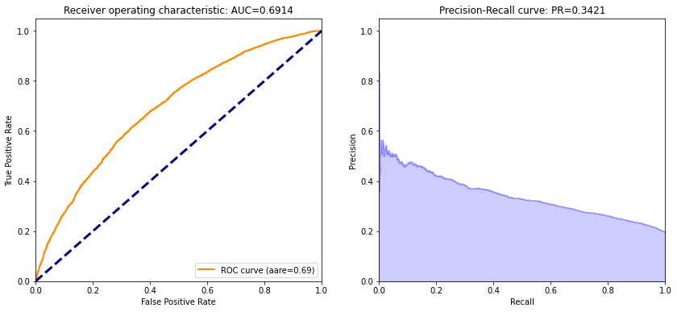

```python
ROC_AUC1(forest, test, 'loan_default') # use p1 in y_pred
```

AUC is equivalent to the probability that a randomly chosen positive instance is ranked higher than a randomly chosen negative instance, In practice, the AUC performs well as a general measure of predictive accuracy. In this case, our AUC is about 0.69, which I think is not very good. Improvements are needed.

```python
createGains(forest)
```

```
drf prediction progress: |███████████████████████████████████████████████████████| (done) 100%
```

| decile | count | actual | non_actual | cum_count | cum_actual | cum_non_actual | percent_cum_actual | percent_cum_non_actual | if_random | lift | K_S | gain |
| --- | --- | --- | --- | --- | --- | --- | --- | --- | --- | --- | --- | --- |
| 0 | 1600 | 470 | 1130 | 1600 | 470 | 1130 | 0.15 | 0.09 | 309.8 | 1.52 | 6.0 | 29.38 |
| 1 | 1600 | 450 | 1150 | 3200 | 920 | 2280 | 0.30 | 0.18 | 619.6 | 1.48 | 12.0 | 28.75 |
| 2 | 1600 | 474 | 1126 | 4800 | 1394 | 3406 | 0.45 | 0.26 | 929.4 | 1.50 | 19.0 | 29.04 |
| 3 | 1600 | 467 | 1133 | 6400 | 1861 | 4539 | 0.60 | 0.35 | 1239.2 | 1.50 | 25.0 | 29.08 |
| 4 | 1600 | 302 | 1298 | 8000 | 2163 | 5837 | 0.70 | 0.45 | 1549.0 | 1.40 | 25.0 | 27.04 |
| 5 | 1600 | 199 | 1401 | 9600 | 2362 | 7238 | 0.76 | 0.56 | 1858.8 | 1.27 | 20.0 | 24.60 |
| 6 | 1600 | 199 | 1401 | 11200 | 2561 | 8639 | 0.83 | 0.67 | 2168.6 | 1.18 | 16.0 | 22.87 |
| 7 | 1600 | 185 | 1415 | 12800 | 2746 | 10054 | 0.89 | 0.78 | 2478.4 | 1.11 | 11.0 | 21.45 |
| 8 | 1600 | 171 | 1429 | 14400 | 2917 | 11483 | 0.94 | 0.89 | 2788.2 | 1.05 | 5.0 | 20.26 |
| 9 | 1600 | 181 | 1419 | 16000 | 3098 | 12902 | 1.00 | 1.00 | 3098.0 | 1.00 | 0.0 | 19.36 |

From the Gains and lift table above, we notice that values in column *actual* are not decreasing monotonically. This means we cannot put our model into production